# homework2

yuseungyeon

2020년 9월 13일

#### 1. Draw time seires graph of sun spot. Do you see any cycle or seasonal effect?

일정 주기를 가지고 반복되는 형태를 보이고 있으므로 순환변동 형태를 보이고 있다.

```r
require(graphics)
data.ts = ts(data=data, start=c(1960,1), frequency = 4)
data.ts
```

```
##      Qtr1 Qtr2 Qtr3 Qtr4
## 1960  101   82   66   35
## 1961   31    7   20   92
## 1962  154  125   85   68
## 1963   38   23   10   24
## 1964   83  132  131  118
## 1965   90   67   60   47
## 1966   41   21   16    6
## 1967    4    7   14   34
## 1968   45   43   48   42
## 1969   28   10    8    2
## 1970    0    1    5   12
## 1971   14   35   46   41
## 1972   30   24   16    7
## 1973    4    2    8   17
## 1974   36   50   62   67
## 1975   71   48   28    8
## 1976   13   57  122  138
## 1977  103   86   63   37
## 1978   24   11   15   40
## 1979   62   98  124   96
## 1980   66   64   54   39
## 1981   21    7    4   23
## 1982   55   94   96   77
## 1983   59   44   47   30
## 1984   16    7   37   74
```

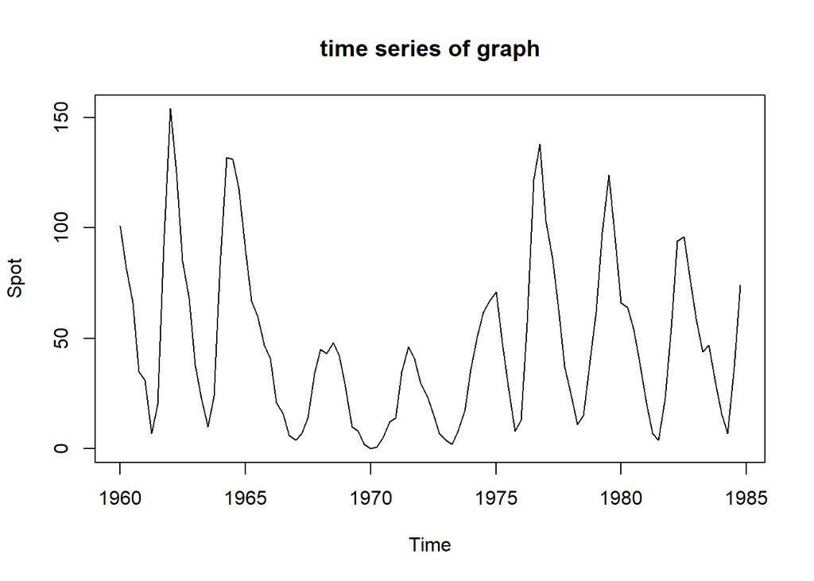

```r
plot(data.ts, mai="time series of graph")
```

#### 2. Try 5-point moving average smoothing. Draw the plot of original graph in black, 4 point MA smoothing in red, mean value blue.

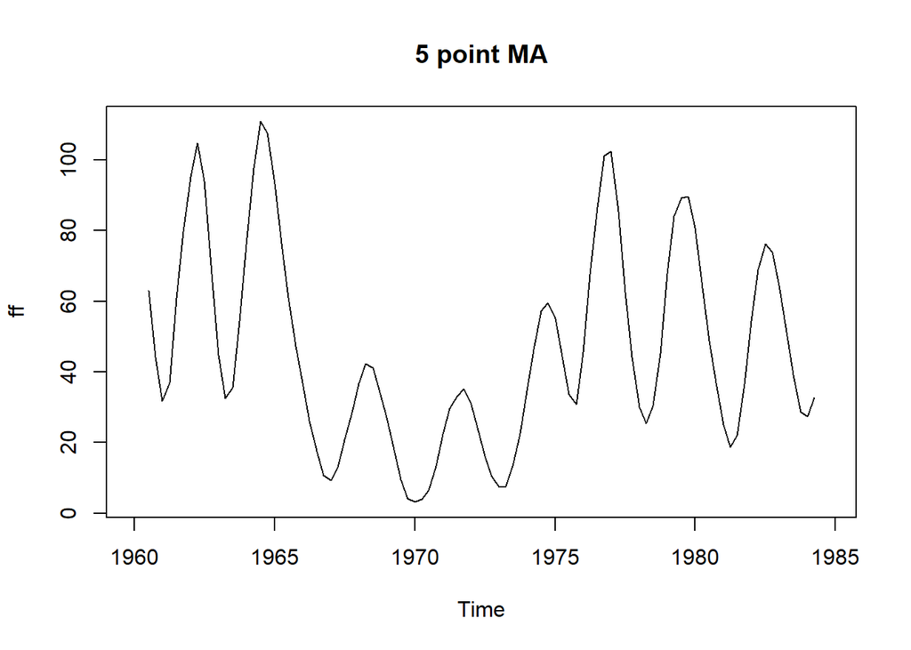

```r
ff <- filter(data.ts, filter=rep(1/5,5))
plot(ff, main="5 point MA")
```

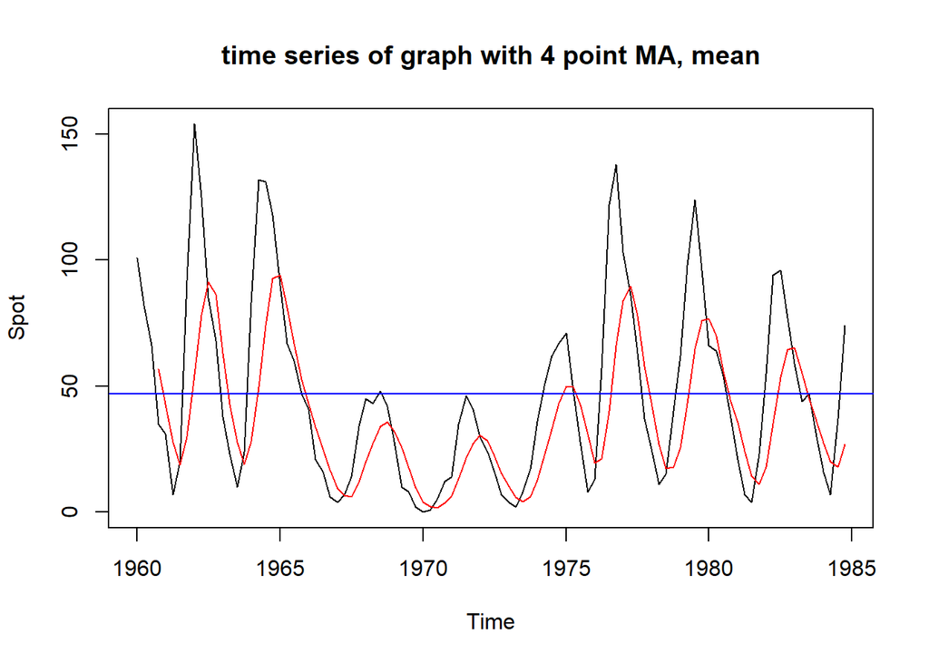

```r
plot(data.ts, mai="time series of graph with 4 point MA, mean")
ff1 <- filter(data.ts, filter=rep(1,4)/5, method="convolution", sides=1)
lines(ff1, col="red")
abline(h=mean(data[,1]), col="blue")
```

#### 3. Check the residual plot, check the staionary and the test the independence assumption. Carefully interpret the residual analysis.

초기의 값들은 잔차가 유의수준을 넘어가고 있다. 그렇지만 후반으로 갈수록 잔차가 유의수준을 벗어나지 않고 있다. 여기에서 우리는 정상성을 만족하지 않는다고 판단한다.

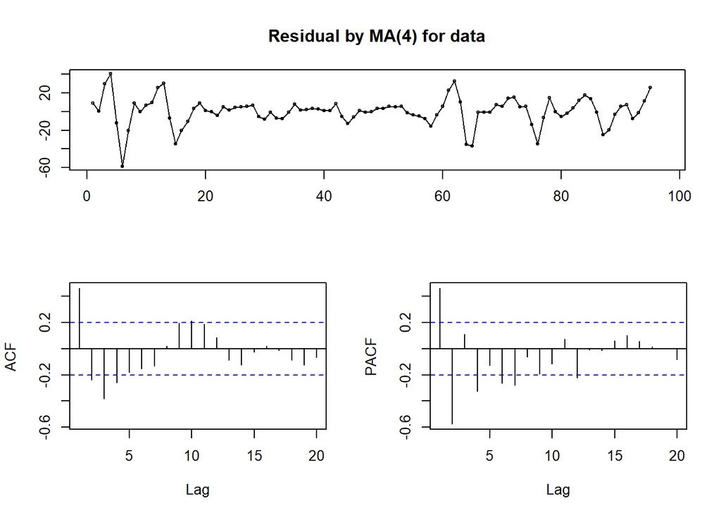

```r
library(forecast)
res = ff[-1:-3,]-data.ts[-1:-3,]
tsdisplay(res ,main="Residual by MA(4) for data")
```

H0 : 독립성을 가지고 있다. vs H1 : not H0 Box-Pierce test p-value의 값이 0.05를 넘지 않으므로 H0를 기각한다. 데이터는 독립성을 가지지 않는 것으로 볼 수 있다.

```r
Box.test(res, type="Box-Pierce")
```

```
##
##  Box-Pierce test
##
## data:  res
## X-squared = 20.168, df = 1, p-value = 7.092e-06
```

#### 4. Fit the simple exponential smoothing with alpha=0.1 and with the optimized alpha. If you think we need a trend, or seasonal, or both try them. Please address all the modeling and show how you find the best exponential smoothing model for spot data.

추세나 계절변동은 보이지 않는 것으로 간주하여 지수평활법을 적용한다. 예측값은 후자가 더 유사한 것으로 보이므로 ho에 대해 좀 더 자세히 살펴보기로 한다.

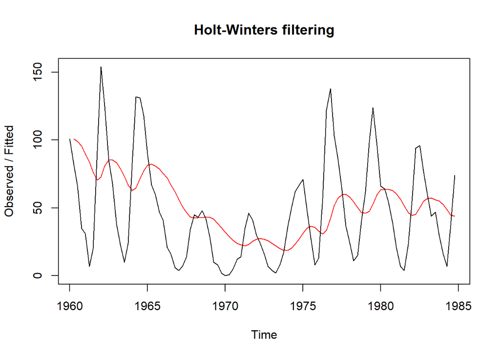

```r
ha <- HoltWinters(data.ts, alpha=0.1, beta=FALSE, gamma=FALSE)
ho <- HoltWinters(data.ts, beta=FALSE, gamma=FALSE)
plot(ha)
```

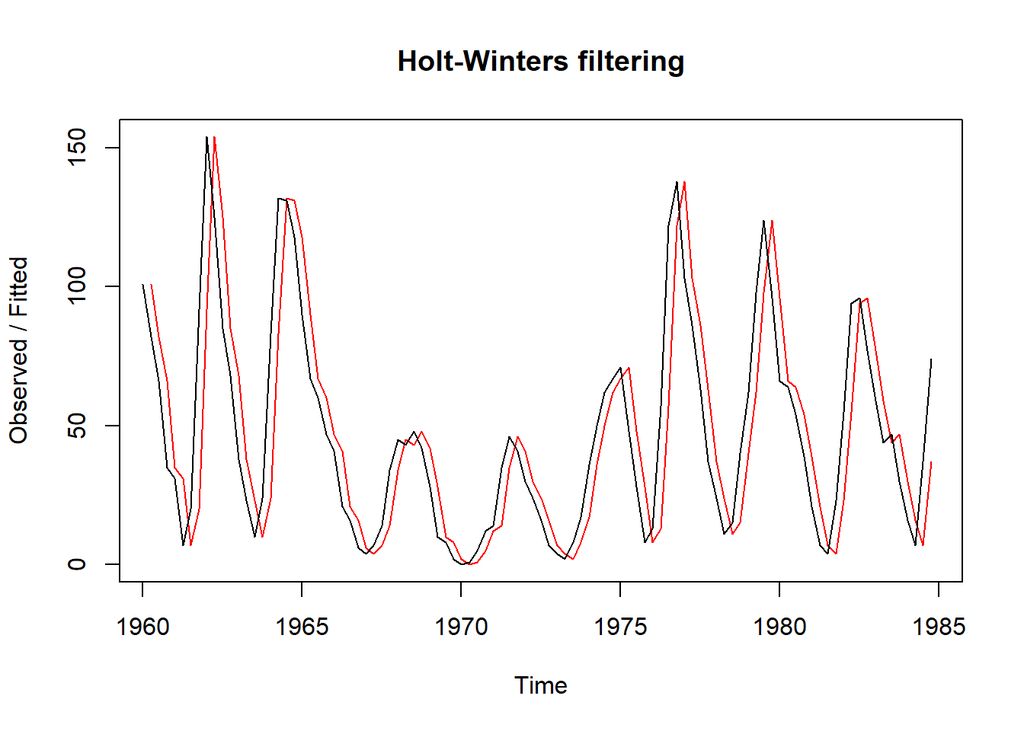

```r
plot(ho)
```

앞서 살펴본 모형처럼 초기의 값들은 잔차가 유의수준을 넘어가고 있다. 그렇지만 후반으로 갈수록 잔차가 유의수준을 벗어나지 않고 있다. 여기에서 우리는 정상성을 만족하지 않는다고 판단한다.

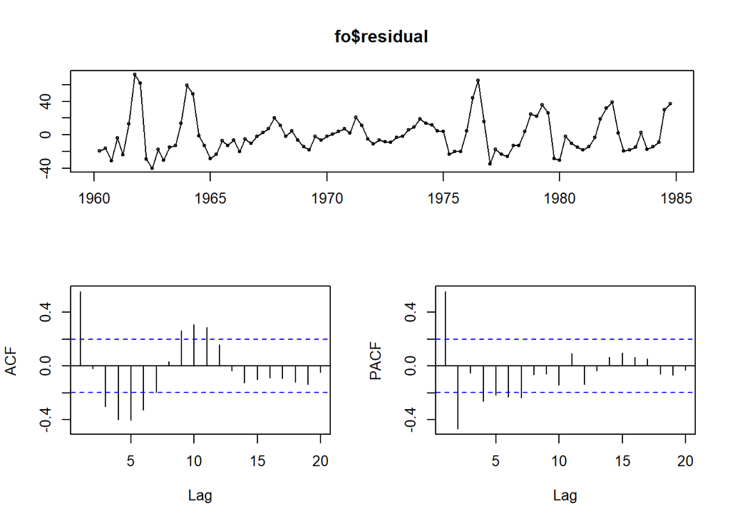

```r
fo <- forecast(ho)
tsdisplay(fo$residual)
```

H0 : 독립성을 가지고 있다. vs H1 : not H0 Box-Pierce test p-value의 값이 0.05를 넘지 않으므로 H0를 기각한다. 데이터는 독립성을 가지지 않는 것으로 볼 수 있다.

```r
Box.test(fo$residuals, type="Box-Pierce")
```

```
##
##  Box-Pierce test
##
## data:  fo$residuals
## X-squared = 30.077, df = 1, p-value = 4.153e-08
```

#### 5. From your best model, find the forecast of next 4 points.

4점의 예측은 모두 같은 값으로 나오지만, 예측구간은 점차 넓어지는 것을 볼 수 있다.

```r
fo <- forecast(ho, h=4)
fo
```

```
##         Point Forecast    Lo 80    Hi 80      Lo 95    Hi 95
## 1985 Q1       73.99755 45.07885 102.9163  29.770210 118.2249
## 1985 Q2       73.99755 33.10168 114.8934  11.452711 136.5424
## 1985 Q3       73.99755 23.91109 124.0840  -2.603077 150.5982
## 1985 Q4       73.99755 16.16301 131.8321 -14.452749 162.4479
```

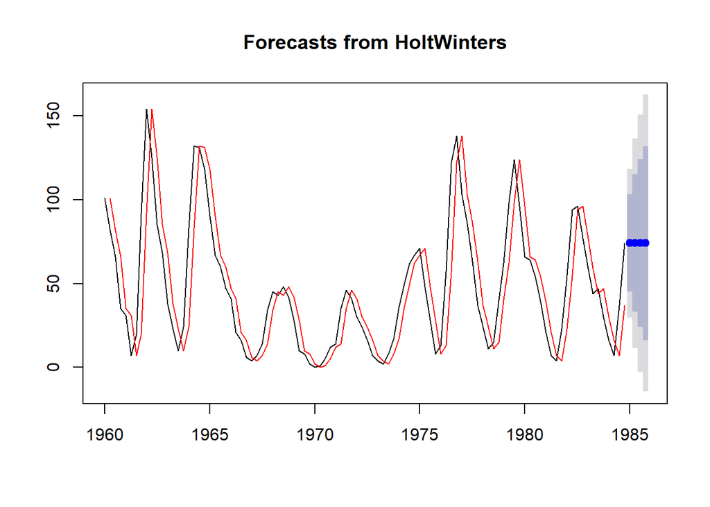

```r
plot(fo)
lines(fo$fitted, col="red")
```